# Prediction Assignment Writeup

Enrique Ripoll

19th December 2017

## Summary

People regularly quantify *how much* of a particular activity they do, but they rarely quantify *how well* they do it. Using data from accelerometers on the belt, forearm, arm, and dumbell of 6 participants, the goal of this project is to predict the manner in which they did the Unilateral Dumbbell Biceps Curl excercise.

## Loading the data

As first step, we should download the data and load the data sets into R

```r
setwd("C:/Users/daiko/Documents/DATA_SCIENCE/000_Coursera/Course_8");

urltrain <- "https://d396qusza40orc.cloudfront.net/predmachlearn/pml-training.csv"
urltest <- "https://d396qusza40orc.cloudfront.net/predmachlearn/pml-testing.csv"
fnametrain <- "./pml-training.csv"
fnametest <- "./pml-testing.csv"

if(!file.exists(fnametrain))   download.file(urltrain, destfile = fnametrain);
if(!file.exists(fnametest))    download.file(urltest, destfile = fnametest);

dtrain0 <- read.csv (fnametrain)
dtest0 <- read.csv (fnametest)
```

## Preprocessing

If we take a look to the (train) data set, the outcome is the variable *classe*, which is a factor variable that classifies the excersice in five different fashions: exactly according to the specification (Class A), throwing the elbows to the front (Class B), lifting the dumbbell only halfway (Class C), lowering the dumbbell only halfway (Class D) and throwing the hips to the front (Class E).

The data set contains 160 variables. However, the variables [1,3,4,5,6,7] are irrelevant as predictors and there are also some variables with NA values. So we are going to remove this variables in order to clean the data.

```r
dtrain <- dtrain0[,-c(1,3,4,5,6,7)]
dtrain <- dtrain[, colSums(is.na(dtrain)) == 0]
dtrain <- dtrain[,-which(sapply(dtrain, class) == "factor")] #Eliminate columns coded as factor
#re-including two removed factor variables that we need to use
dtrain$user_name <- dtrain0$user_name
dtrain$classe <- dtrain0$classe
```

## Machine Learning

### Data splitting and cross-validation

We are going to split the training set in two subsets: the subtraining set and the subtesting set. This will allow us to cross-validate the model, building a model on the subtraining test, evaluating on the subtesting set and repeating and averaging the estimated errors.

```r
set.seed(112)
inTrain <- createDataPartition(y=dtrain$classe, p=0.7)[[1]]
dsubtrain <- dtrain[inTrain,]
dsubtest <- dtrain[-inTrain,]
```

```r
control <- trainControl(method = "cv", number = 6)
```

### Training the model

Since this is mainly a classification project, we are going to use *boosting* and *rain forest* as learning methods, and compare the results

*Boosting* was a procedure that combines the outputs of many “weak” classifiers to produce a powerful “committee”. We control the tuning parameters with the function “expand.grid”

```r
set.seed(112)
modelgrid <- expand.grid (interaction.depth = round(sqrt(NCOL(dsubtrain))),
                         n.trees = c(50, 100, 200),
                         shrinkage = 0.1,
                         n.minobsinnode = c(10,20))

modelBoost <- train (classe ~ ., data=dsubtrain, method="gbm", verbose=FALSE,
              preProc = c("center", "scale"),
              trControl=control,
              tuneGrid = modelgrid)
modelBoost$results
```

```
##   shrinkage interaction.depth n.minobsinnode n.trees  Accuracy     Kappa
## 1       0.1                 7             10      50 0.9586523 0.9476763
## 4       0.1                 7             20      50 0.9581423 0.9470331
## 2       0.1                 7             10     100 0.9798353 0.9744901
## 5       0.1                 7             20     100 0.9820919 0.9773470
## 3       0.1                 7             10     200 0.9890807 0.9861887
## 6       0.1                 7             20     200 0.9910465 0.9886758
##    AccuracySD     KappaSD
## 1 0.004736931 0.006001903
## 4 0.005452266 0.006900333
## 2 0.002203148 0.002790790
## 5 0.001683415 0.002130524
## 3 0.001990898 0.002518866
## 6 0.002480278 0.003136755
```

*Random forest* are also a procedure for classification and operate by constructing a multitude of decision trees at training time and outputting the class that is the mode of the classes

```r
set.seed(112)
modelgrid2 <- expand.grid(.mtry=c(5,10,15,20))
modelForest <- train(classe ~ ., data=dsubtrain, method="rf",
                   preProc = c("center", "scale"),
                   trControl=control,
                   tuneGrid = modelgrid2)
modelForest$results
```

```
##   mtry  Accuracy     Kappa  AccuracySD     KappaSD
## 1    5 0.9928659 0.9909758 0.001718496 0.002174218
## 2   10 0.9922838 0.9902398 0.002060550 0.002606057
## 3   15 0.9919199 0.9897800 0.001985569 0.002510742
## 4   20 0.9914103 0.9891351 0.002040897 0.002581196
```

### Results

In order to obtain the out-sample error we use the Confussion Matrix, that compare the truth values of the subtesting set (that we have still not use) with the predictions, for both boosting and rain forest methods

```r
CMBoost <- confusionMatrix(dsubtest$classe, predict(modelBoost, dsubtest))
CMForest <- confusionMatrix(dsubtest$classe, predict(modelForest, dsubtest))
```

The test accuracy is 0.9923534 for boosting model and 0.9935429 for rain forest model. Let’s see what are the most important variable in both models:

Rain Forest model:

```r
varImp(modelForest)
```

```
## rf variable importance
##
##   only 20 most important variables shown (out of 57)
##
##                      Overall
## roll_belt             100.00
## yaw_belt               76.75
## magnet_dumbbell_z      62.67
## pitch_forearm          60.98
## magnet_dumbbell_y      59.23
## pitch_belt             59.10
## roll_forearm           50.56
## magnet_dumbbell_x      46.06
## roll_dumbbell          40.39
## magnet_belt_z          39.73
## accel_dumbbell_y       37.06
## magnet_belt_y          36.43
## accel_belt_z           36.14
## accel_dumbbell_z       34.22
## accel_forearm_x        30.57
## gyros_belt_z           30.27
## roll_arm               28.47
## total_accel_dumbbell   25.33
## yaw_dumbbell           25.17
## accel_dumbbell_x       25.05
```

Boosting model:

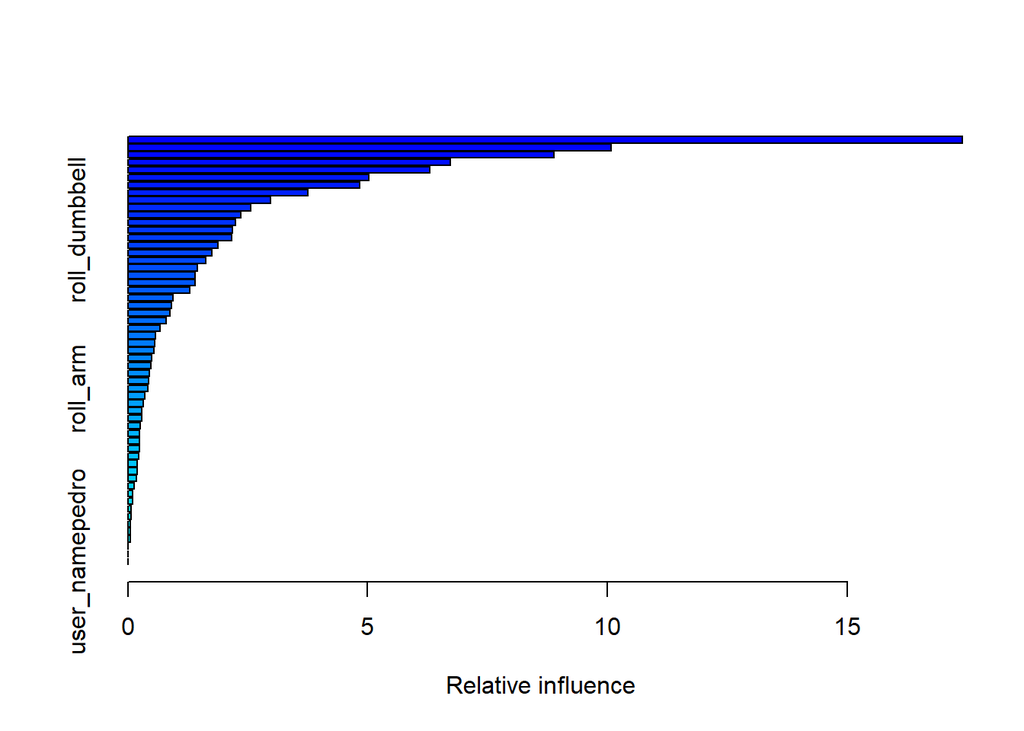

```
##                                 var   rel.inf
## roll_belt                 roll_belt 17.403429
## yaw_belt                   yaw_belt 10.071318
## pitch_forearm         pitch_forearm  8.890047
## magnet_dumbbell_z magnet_dumbbell_z  6.720207
## magnet_dumbbell_y magnet_dumbbell_y  6.294065
## roll_forearm           roll_forearm  5.031690
## pitch_belt               pitch_belt  4.838925
## magnet_belt_z         magnet_belt_z  3.760095
## gyros_belt_z           gyros_belt_z  2.971410
## accel_dumbbell_y   accel_dumbbell_y  2.554127
```

```r
head(summary(modelBoost$finalModel),10)
```

```r
p1 <- ggplot(dsubtrain, aes(x=roll_belt, y=pitch_forearm, colour=classe)) +
      geom_point() + theme_minimal() +
      labs (title = "SubTraining set")
```

## Prediction

Once we have trained our model(s), we could use them to predict the outcome for the original test set, that have still not been used.

```r
predictionBoost <- predict(modelBoost, dtest0)
predictionForest <- predict(modelForest, dtest0)
prediction <- data.frame(id=dtest0$problem_id, name=dtest0$user_name, Boosting_classe=predictionBoost,
                         RForest_classe=predictionForest)
prediction
```

```
##    id     name Boosting_classe RForest_classe
## 1   1    pedro               B              B
## 2   2   jeremy               A              A
## 3   3   jeremy               B              B
## 4   4   adelmo               A              A
## 5   5   eurico               A              A
## 6   6   jeremy               E              E
## 7   7   jeremy               D              D
## 8   8   jeremy               B              B
## 9   9 carlitos               A              A
## 10 10  charles               A              A
## 11 11 carlitos               B              B
## 12 12   jeremy               C              C
## 13 13   eurico               B              B
## 14 14   jeremy               A              A
## 15 15   jeremy               E              E
## 16 16   eurico               E              E
## 17 17    pedro               A              A
## 18 18 carlitos               B              B
## 19 19    pedro               B              B
## 20 20   eurico               B              B
```

## Conclusions

```r
kable(CMBoost$table, caption = "Boosting method")
```

Boosting method

|  | A | B | C | D | E |
| --- | --- | --- | --- | --- | --- |
| A | 1670 | 4 | 0 | 0 | 0 |
| B | 2 | 1132 | 5 | 0 | 0 |
| C | 0 | 9 | 1012 | 5 | 0 |
| D | 0 | 0 | 12 | 949 | 3 |
| E | 0 | 2 | 0 | 3 | 1077 |

```r
kable(CMForest$table, caption = "Random Forest method")
```

Random Forest method

|  | A | B | C | D | E |
| --- | --- | --- | --- | --- | --- |
| A | 1672 | 2 | 0 | 0 | 0 |
| B | 3 | 1132 | 4 | 0 | 0 |
| C | 0 | 7 | 1018 | 1 | 0 |
| D | 0 | 0 | 18 | 945 | 1 |
| E | 0 | 0 | 0 | 2 | 1080 |

Finally, both models have been applied to predict the *classe* of an (unused) validation data set, showing both identical results as expected.